# Exercise 1

```python
import pandas as pd
import numpy as np
import matplotlib.pyplot as plt

n = 1000000

y = np.zeros(n)
for i in range(len(y)):
    y[i] = np.sum(np.random.random(12)) -6  # Sum of 12 numbers, uniformly generated in the range 0,1 minus 6
```

# Plot histogram

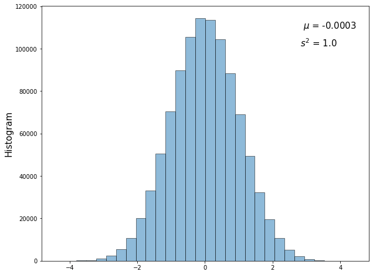

```python
mean = np.round(np.mean(y),4)
var = np.round(np.var(y),4)


fig, ax = plt.subplots(figsize=(10, 8),
                              sharey=True)
ax.hist(y, alpha=0.5,bins= 30, histtype='bar', ec='black', label='$μ$ = {}'.format(mean))

ax.set_ylabel('Histogram',fontsize=15)
#plt.legend(frameon=False,loc=2,fontsize=12)
ax.text(0.8,0.91,
        '$μ$ = {}'.format(mean), transform=ax.transAxes,fontsize=15)
ax.text(0.79, 0.84,
        '$s^2$ = {}'.format(var), transform=ax.transAxes,fontsize=15)
plt.show()
```

# Comments:

We have shown that the quantity $ y = \sum_{n=1}^{12}x_{n} -6 $, where $x_{n}$ is uniformly distributed pseudo-random number between 0 and 1, is approximately normally distributed with a mean, $\mu \simeq 0$ and variance, $ s^{2} \simeq 1$

# Compare with a normal distribution

# Define function for PDF

```python
def pdf(val, bins,loglog,density):

    if loglog ==1:
        binsa = np.logsspace(np.log10(min(val)),np.log10(max(val)),bins)
    else:
        binsa = np.linspace((min(val)),(max(val)),bins)

    if density ==1:
        norm_counts,edges = np.histogram(val,density= True,bins=binsa)
    else:
        norm_counts,edges = np.histogram(val,density= False,bins=binsa)

    bin_centers  = edges[:-1] + (edges[1:] - edges[:-1])

    return  bin_centers, norm_counts
```

# Generate normal distribution

```python
mu, sigma = 0, 1 # mean and standard deviation
s = np.random.normal(mu, sigma, 1000000)


mean = np.round(np.mean(s),4)
var = np.round(np.var(s),4)
```

# Plot results

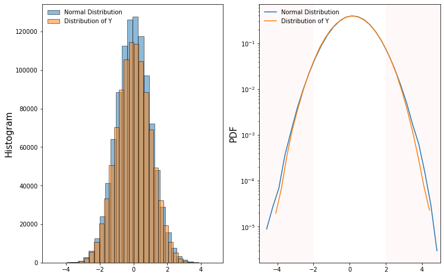

```python
fig, (ax1, ax2) = plt.subplots(1, 2, figsize=(12, 8))


ax1.hist(s, alpha=0.5,bins= 30, histtype='bar', ec='black', label='Normal Distribution')
ax1.hist(y, alpha=0.5,bins= 30, histtype='bar', ec='black', label='Distribution of Y')
#plt.hist(y, alpha=0.5, histtype='bar', ec='black', label='$μ$ = {}'.format(var))
ax1.set_ylabel('Histogram',fontsize=15)
ax1.legend(frameon=False,loc=2,fontsize=10)


# Plot PDF

bins2  = 30
loglog = 0
density = 1

bin_centers_s, norm_counts_s  = pdf(s, bins2,loglog,density)
bin_centers_y, norm_counts_y  = pdf(y, bins2,loglog,density)

ax2.plot(bin_centers_s, norm_counts_s, label='Normal Distribution')
ax2.plot(bin_centers_y, norm_counts_y, label='Distribution of Y')

ax2.set_ylabel('PDF',fontsize=15)
ax2.legend(frameon=False,loc=2,fontsize=10)
ax2.set_yscale('log')
#ax2.axvline(x=-2, color='black',ls='-.',linewidth =0.5)
#ax2.axvline(x=2, color='black',ls='-.', linewidth =0.5)


ax2.axvspan(-5, -2, color='pink', alpha=0.1, lw=0)
ax2.axvspan(2, 5, color='pink', alpha=0.1, lw=0)
ax2.set_xlim([-5,5])

plt.show()
```

# Comments:

We can see that the true Normal distribution has a greater percentage of values with magnitude $|x|>2$, shaded regions in the right hand side panel of the above figure.

# What is the percentage of those values greater than 2 ?

```python
y_new1 = y[y>2]
y_new2 = y[y<-2]

percentage = ((len(y_new1)+len(y_new1))/len(y))*100

print('The percentage of the values of y that have magnitude greater than 2 is {} %'.format(percentage))
```

```
The percentage of the values of y that have magnitude greater than 2 is 4.4886 %
```

# How does this compare with a normal distribution?

```python
s_new1 = s[s>2]
s_new2 = s[s<-2]
percentage = ((len(s_new1)+len(s_new2))/len(s))*100

print('The percentage of the values of the Normal distribution that have magnitude greater than 2 is {} %'.format(percentage))
```

```
The percentage of the values of the Normal distribution that have magnitude greater than 2 is 4.5559 %
```

# Exercise 3 : Numerical Integration of Second order, inhomogeneous DE using RK4

# Define functions

```python
import pandas as pd
import numpy as np
import matplotlib.pyplot as plt
from numba import jit,njit,prange
from mpl_toolkits.axes_grid.inset_locator import inset_axes


def ODE(x, t):
    return  np.array([x[1],  -11*x[1] - 10*x[0] + t**2 ])

def rk4(f, y0, t0, tf, dt):

    t = np.arange(t0, tf, dt)
    y = np.zeros(( t.size, y0.size))

    y[0] = y0

    for i in range(t.size - 1):
        h = dt
        k1 = f(y[i], t[i])
        k2 = f(y[i] + k1 * h / 2., t[i] + h / 2.)
        k3 = f(y[i] + k2 * h / 2., t[i] + h / 2.)
        k4 = f(y[i] + k3 * h, t[i] + h)
        y[i+1] = y[i] + (h / 6.) * (k1 + 2*k2 + 2*k3 + k4)
    return y,t
```

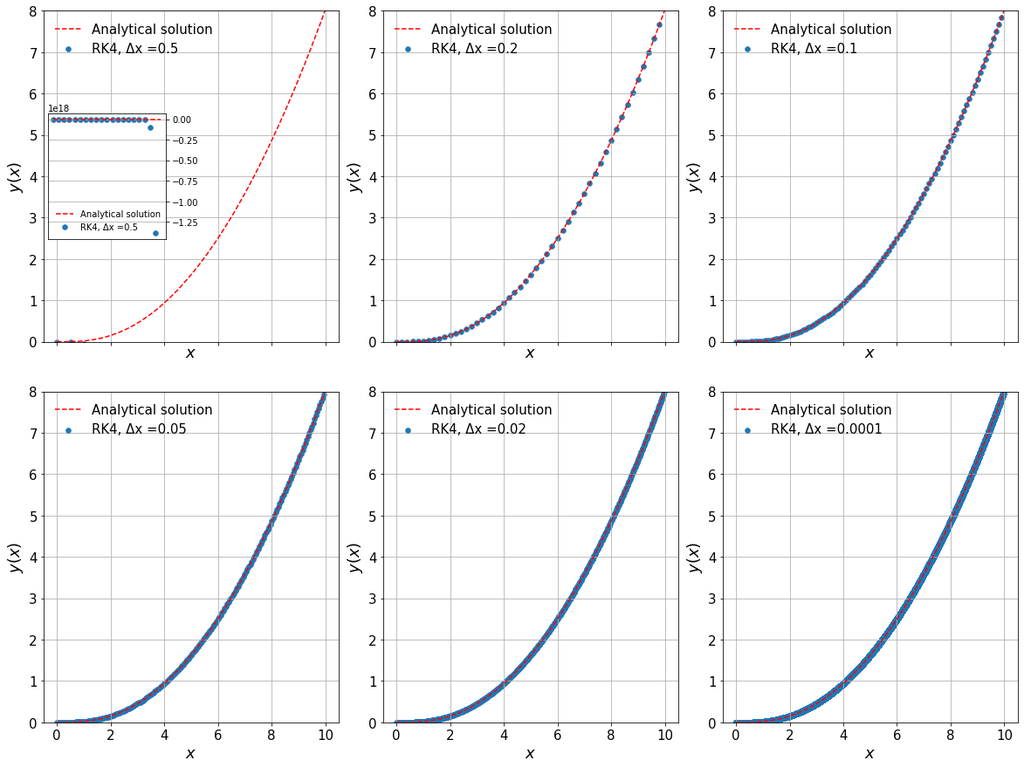

```python
# Choose Boundary and Initial conditions

x0 = np.array([0,0])              # Boundary conditions

t0   = 0
tf   = 10                         # Initial conditions
dt1 = [0.5, 0.2, 0.1, 0.05, 0.02, 0.0001 ]


# Plot analytical solution for comparison
xpts = np.linspace(0, 10, 1001)
f1  = lambda x: -(10/45)*np.exp(-x) + (1/4500)*np.exp(-10*x) +  (x**2/10) -11*x/50 + 111/500

# Plot results

fig, axs = plt.subplots(nrows=2, ncols=3, sharex=True, figsize=(20,15))
fig.subplots_adjust(hspace = .15, wspace=.15)

data = np.arange(0, len(dt1))
for ax, d in zip(axs.ravel(), data):
    dt  = dt1[d]
    sol,t = rk4(ODE, x0, t0, tf, dt)
    ax.scatter(t, sol[:, 0],linewidth =0.5, label ='RK4, Δx ='+str(dt)+'' )#,label = sorbit[k-1],marker=markers[k-1])
    ax.plot(xpts, f1(xpts),'r--', label = 'Analytical solution')
    if d ==0:
        inset_axes = inset_axes(ax,
                    width="40%", # width = 30% of parent_bbox
                    height=2.0, # height : 1 inch
                    loc='center left')
        plt.scatter(t, sol[:, 0],linewidth =0.5, label ='RK4, Δx ='+str(dt)+'' )#,label = sorbit[k-1],marker=markers[k-1])
        plt.plot(xpts, f1(xpts),'r--', label = 'Analytical solution')
        plt.xticks([])

        plt.tick_params(axis='y', which='both', labelleft=False, labelright=True,left=False, right=True)
        plt.legend(frameon=False,loc=3)
        plt.grid()

    ax.grid()
    ax.legend(frameon=False,loc=2,fontsize=15,)
    ax.set_xlabel('$x$',fontsize=18)
    ax.set_ylabel('$y(x)$',fontsize=18)
    ax.tick_params(axis='both',labelsize=15)
    ax.set_ylim([0,8])
    plt.grid()


fig.savefig(r'C:\Users\nikos.000\Current_sheets\figures\rk4.png', format='png',dpi=300,bbox_inches='tight')
```

# Comments for exercise 3:

In this figure, the blue and red dashed line show the evolution of y as a function of x when we solve the Equations using RK4 method, and the analytical solution respectively. We can see that the solution depends significantly on the time step ∆x that we choose. In Fig. 1a the time-step was chosen at ∆x = 0.5. We can see that the solution very quickly diverges to minus infinity.

A stiff differential equation problem is a system for which certain numerical methods for solving the equations are numerically unstable. However, the condition $|x_{n+1}| \leq |x_{n}|$, tells us that even for a stiff problem the solution will stay bound. This is the definition of A-stability. From the inset in Fig. 1a we can see that for $Δ_{x} =0.5$ that the solution goes to minus infinity.

Reducing the timestep to ∆x = 0.2 and then to even smaller values (Fig. b to f), improves the accuracy of the method significantly. We can observe the analytical solution matches the numerical one.

I suspect that for values of $ ∆x \in (0.5, 0.2)$ the solution will oscilate but will stay bounded.

# Exercise 4: Logistic Map

# We define the logistic function by:

# $f_{r}(x)=αx(1−x)$

# Define function

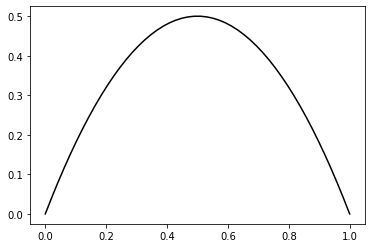

```python
import numpy as np
import matplotlib.pyplot as plt
%matplotlib inline

def logis(r, x):
    return r * x * (1 - x)

x = np.linspace(0, 1)
fig, ax = plt.subplots(1, 1)
ax.plot(x, logis(2, x), 'k')
```

# Discrete dynamical system as defined by the recursive application of the logistic function

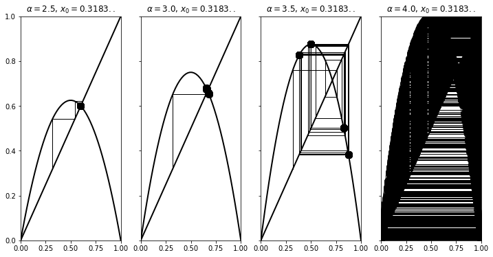

```python
def plt_s(r, x0, n, ax=None):
    # Plot the function,  y=x  line.
    t = np.linspace(0, 1)
    ax.plot(t, logis(r, t), 'k', lw=2)
    ax.plot([0, 1], [0, 1], 'k', lw=2)

    # Recursively apply y=f(x) and plot two lines:
    # (x, x) -> (x, y)
    # (x, y) -> (y, y)
    x = x0
    for i in range(n):
        y = logis(r, x)
        # Plot the two lines.
        ax.plot([x, x], [x, y], 'k', lw=1)
        ax.plot([x, y], [y, y], 'k', lw=1)
        # Plot the positions with increasing
        # opacity.
        ax.plot([x], [y], 'ok', ms=10,
                alpha=(i + 1) / n)
        x = y

    ax.set_xlim(0, 1)
    ax.set_ylim(0, 1)
    ax.set_title(f"$α={r:.1f}, \, x_0={x0:.4f}..$")


fig, (ax1, ax2, ax3, ax4) = plt.subplots(1, 4, figsize=(12, 6),
                               sharey=True)
plt_s(2.5, 1/np.pi, 1000, ax=ax1)
plt_s(3, 1/np.pi, 1000, ax=ax2)
plt_s(3.5, 1/np.pi, 1000, ax=ax3)
plt_s(4, 1/np.pi, 1000, ax=ax4)
```

# Comments:

# Specify number of different r's, number of iterations

```python
n = 10000
r = np.linspace(2.5, 4.0, n)

iterations = 1000
last = 100
```

# $ x_{0} = 1/π $

```python
x = (1/np.pi)* np.ones(n)
```

# Plot bifurcation diagram

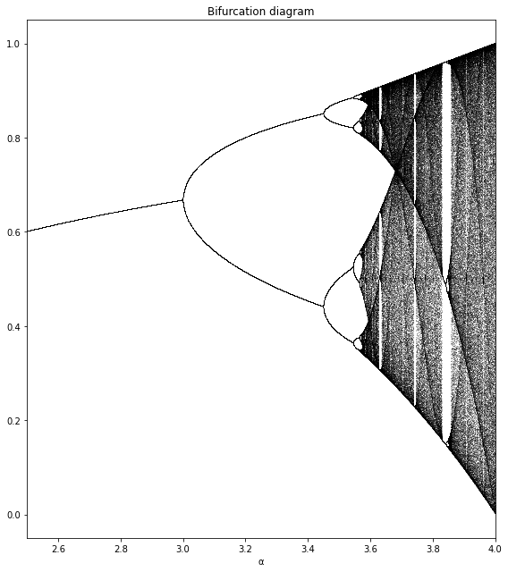

```python
fig, ax1 = plt.subplots( figsize=(8, 9),
                               sharex=True)
for i in range(iterations):
    x = logis(r, x)
    if i >= (iterations - last):
        ax1.plot(r, x, ',k', alpha=.25)
ax1.set_xlim(2.5, 4)
ax1.set_title("Bifurcation diagram")
ax1.set_xlabel("α")

plt.tight_layout()
```

# We can observe that:

There are two fixed points, $x^{*}$ for this map, one at $x_{1}^{*} = 0$ and another r-dependent given by $x_{2}^{*} = (1 - 1/r)$ . A transcritical bifurcation is observed at $r = 1$ , where the fixed points $x_{1}$ and $x_{2}$ exchange their stability. For $r>1$ , the fixed point $x_{1}^{*}$ becomes unstable. For $r = 3$ a first period doubling bifurcation happens involving $x_{2}^{*}$ , which defines a route of flip bifurcations, known as Feigenbaum scenario, toward a chaotic dynamics. For $r=4$, the fixed point $x_{1}^{*}$ touches the chaotic attractor at $x = 0$, producing a boundary crisis, hence destroying the attractor.

# For a =4

We therefore turn to the case a =4, the solved analytically. Here, if $X_{0}, = 4 sin^{2}(πθ)$. We find by repeated application of the quadratic equation that: $X_{n} = 4 sin^{2}(2^{n}πθ)$

We see that only the residual of θ modulo 1 is effective in determining X_{n}. In particular, if $θ$ is rational, $2^{n}θ $ eventually differs from θ by an integer, and the solution is periodic. If θ is not rational, the solution is not periodic. Moreover, for almost all the nonperiodic solutions, the values of $2^{n}θ$ modulo 1 have a constant probability density.

# Transformation

```python
import math

def log_new(theta):
    return np.mod(2*theta,2*np.pi)

iterations = 100000

theta0 = math.asin(1/np.pi)
aa =[]

for i in range(iterations):
    theta0 = log_new(theta0)
    aa.append(theta0)
```

# Plot histogram of linear congruential transformation

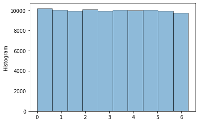

```python
plt.hist(aa, alpha=0.5, histtype='bar', ec='black')
plt.ylabel('Histogram')
plt.show()
```

# Comments:

We can observe that this transformation provides us a crude way to generate pseudo-random numbers over the range from 0 to 2π